# Pregnancy Time Course Quality Control

Karsten Bach

2020-03-07

# Load Data

```r
library(scran)
library(scater)
library(dplyr)
library(knitr)
library(ggplot2)
library(Rtsne)
library(cowplot)
library(Matrix)
library(viridis)
library(DT)
# source("functions.R")
theme_set(theme_cowplot())

# Load Data
sce <- readRDS("../data/Robjects/SCE.rds")

m <- counts(sce)
pD <- data.frame(colData(sce))
fD <- data.frame(rowData(sce))
rm(sce)

# I will also shuffle the rows of pD and columns of m for plotting purpose and to prevent any funny effects from the ordering
set.seed(300)
pD <- pD[sample(nrow(pD)),]
m <- m[,pD$barcode]
pD$Batch <- ifelse(pD$SeqID %in% c("E7","F7","G7"),"2","1")
```

# Overview

- This file contains the quality control for both batches of the pregnancy data set.
- We have sequenced a total of 12 animals, of which we had 3 per Condition.

```r
pD$Batch <- as.factor(pD$Batch)
fP <- summarize(group_by(pD,Batch,Condition,SampleID),n=n())
```

# Number of Cells

- We sequenced slightly more cells than expected, with a total of 130492 cells.

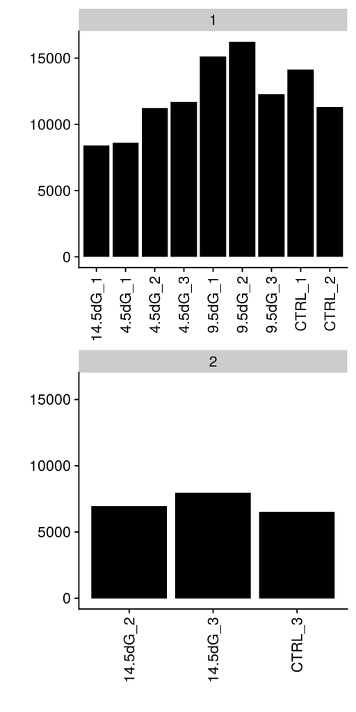

```r
fP <- summarize(group_by(pD,Batch,SampleID),n=n())
ggplot(fP, aes(x=SampleID, y=n)) +
    geom_bar(stat="identity",fill="black") +
    facet_wrap(~Batch,scales="free_x",nrow=2) +
    theme(axis.text.x = element_text(angle = 90, hjust = 1, vjust = 0.5)) +
    xlab("") +
    ylab("")
```

# Quality Control

## Library Sizes

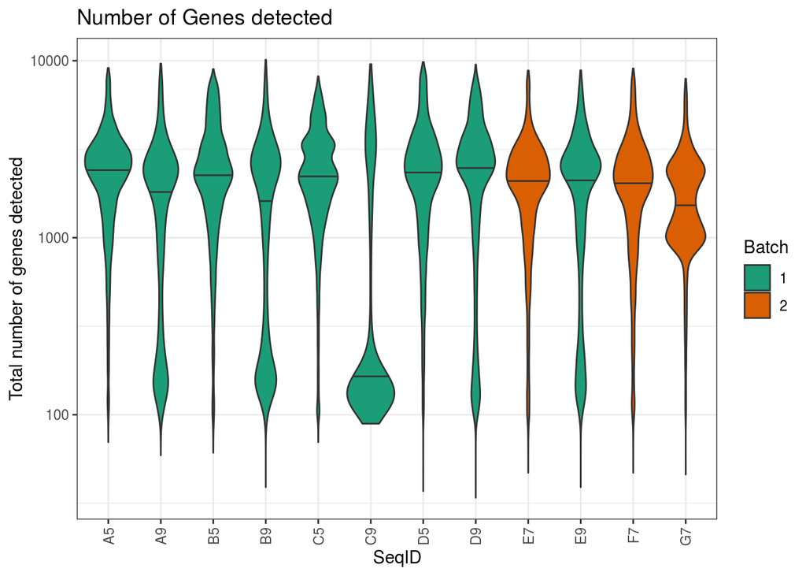

```r
# Sequencing Depth and Genes detected
pD$UmiSums<- colSums(m)
pD$GenesDetected <- colSums(m!=0)
genesDetected <- ggplot(pD, aes(x=SeqID,y=GenesDetected,fill=Batch)) +
    geom_violin(draw_quantiles=0.5)+
    scale_y_log10() +
    ylab("Total number of genes detected") +
    ggtitle("Number of Genes detected") +
    theme_bw() +
    scale_fill_brewer(palette="Dark2") +
    theme(axis.text.x = element_text(angle = 90, hjust = 1, vjust = 0.5))
LibrarySize <- ggplot(pD, aes(x=SampleID,y=UmiSums,fill=Batch)) +
    geom_violin(draw_quantiles=0.5)+
    scale_y_log10() +
    ylab("Total number of molecules") +
    ggtitle("Number of Molecules") +
    theme_bw() +
    scale_fill_brewer(palette="Dark2") +
    theme(axis.text.x = element_text(angle = 90, hjust = 1, vjust = 0.5))

# Cell Viability
mMito <- m[fD$Mitochondrial,]
pD$prcntMito <- colSums(mMito)/colSums(m)
cellViability <- ggplot(pD, aes(x=prcntMito, y=GenesDetected))+
    geom_hex(bins=50) +
    xlab("Percentage of mitochondrial reads") +
    ggtitle("Cell Viability") +
    facet_wrap(~SampleID) +
    scale_fill_viridis()
rm(mMito)

genesDetected
```

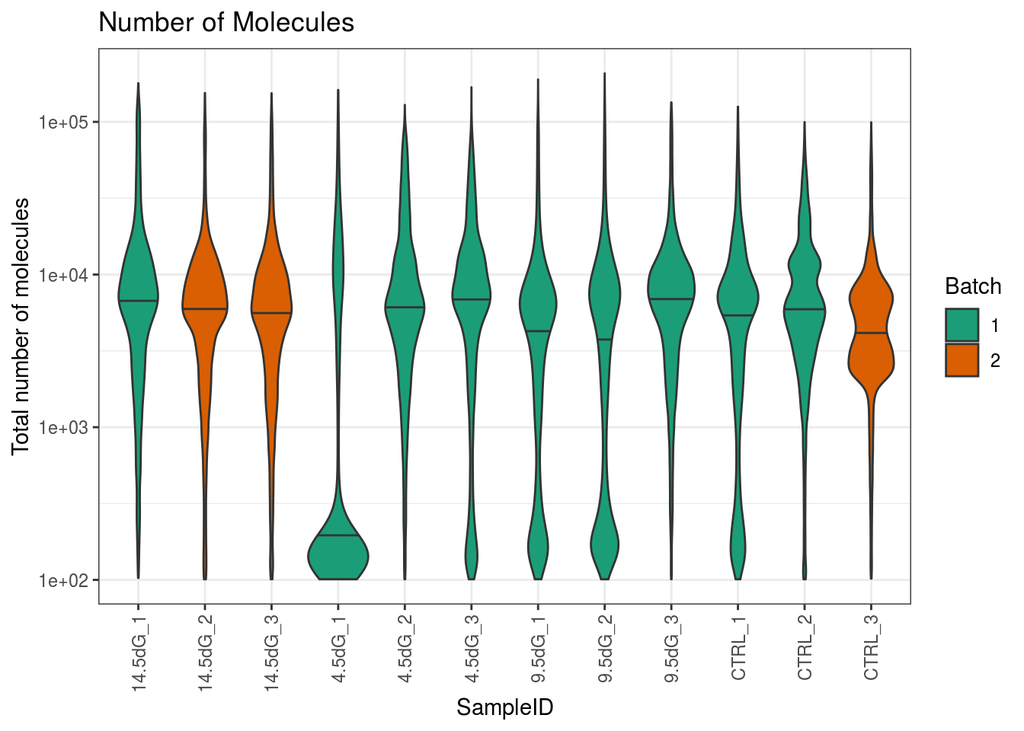

```r
LibrarySize
```

## Viability

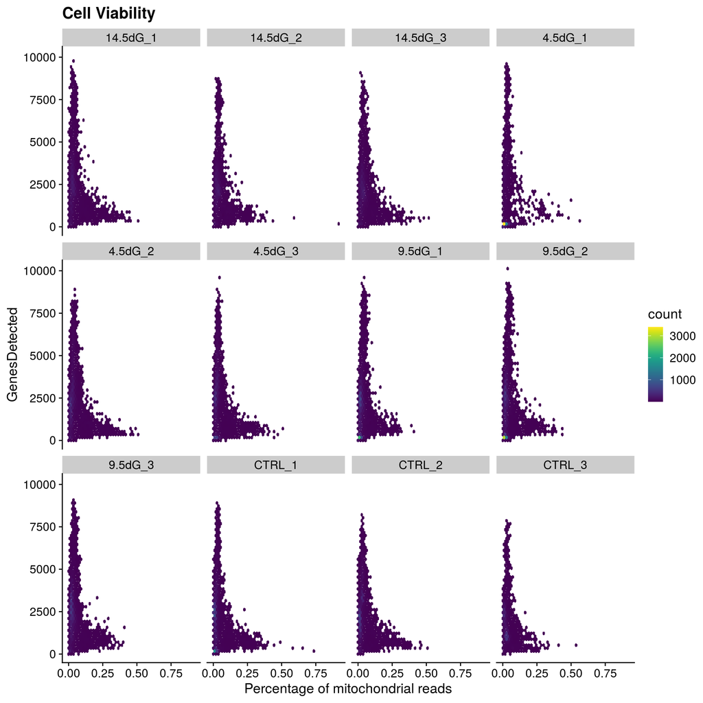

```r
cellViability
```

## Relationship between UmiSums and GenesDetected

- After the intial round of QC I noted that a population of cells that stood out (e.g. in UMAPs) that I could only identify by a substantial lower number of Genes detected for a certain sequencing depth.
- I will flag and remove them here and will need to investigate later if they are enriched for any particular cell type.

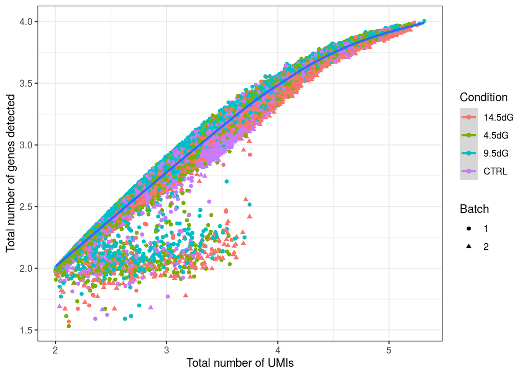

```r
# Sequencing Depth and Genes detected
gDLib <- ggplot(pD, aes(x=log10(UmiSums),y=log10(GenesDetected), color=Condition, shape=Batch)) +
    geom_point() +
    geom_smooth(aes(color=NULL, shape=NULL)) +
    ylab("Total number of genes detected") +
    xlab("Total number of UMIs") +
    theme_bw() +
    scale_fill_brewer(palette="Dark2")
gDLib
```

```r
library(mgcv)
pD$residDetectionTrend <- gam(log10(GenesDetected) ~ s(log10(UmiSums),bs="cr"),data=pD)$residuals
```

## Summary

```r
sumry <- group_by(pD, SampleID) %>%
    summarize("Number of cells"=n(),
          "Total molecules"=median(UmiSums),
          "Genes Detected"=median(GenesDetected))
kable(sumry,caption="Summary of QC parameters as median")
```

Summary of QC parameters as median

| SampleID | Number of cells | Total molecules | Genes Detected |
| --- | --- | --- | --- |
| 14.5dG_1 | 8413 | 6807 | 2354.0 |
| 14.5dG_2 | 6933 | 5968 | 2110.0 |
| 14.5dG_3 | 7954 | 5662 | 2052.0 |
| 4.5dG_1 | 8626 | 163 | 152.0 |
| 4.5dG_2 | 11223 | 6123 | 2262.0 |
| 4.5dG_3 | 11692 | 6890 | 2505.0 |
| 9.5dG_1 | 15114 | 4421 | 1900.5 |
| 9.5dG_2 | 16225 | 3749 | 1675.0 |
| 9.5dG_3 | 12299 | 7005 | 2431.0 |
| CTRL_1 | 14149 | 5626 | 2184.0 |
| CTRL_2 | 11321 | 5935 | 2224.0 |
| CTRL_3 | 6543 | 4144 | 1525.0 |

# QC Filtering

## Cell-wise

```r
lib.outlier <- isOutlier(pD$UmiSums,nmads=3,type="both",log=TRUE)
gd.outlier <- isOutlier(pD$GenesDetected,nmads=3,type="both",log=TRUE)
mt.outlier <- isOutlier(pD$prcntMito,nmads=3,type="higher")
trnd.outlier <- isOutlier(pD$residDetectionTrend,nmads=6,type="lower")

pD$PassLibSize <- !lib.outlier
pD$PassGenesDetected <- !gd.outlier
pD$PassViability <- !mt.outlier
pD$PassTrend <- !trnd.outlier
pD$PassAll <- pD$PassLibSize & pD$PassGenesDetected & pD$PassViability & pD$PassTrend
```

The following filters were applied to remove low quality cells:

- Library size (3 mads from median)
- Number of Genes detected (3 mads from median)
- Mitochondrial reads (3 mads from median)
- In addition I added a filter on the gene detection trend (see above) which was defined as 6 mads from the median residuals of a cubic spline fit
- Overall a relatively high number of cells is flagged with low viability 8261 which is also due to the use of emptyDrops.
- The thresholds are as follows :
  - 207 for UmiSums,
  - 243 for genes detected
  - 0.0642555 for viability.

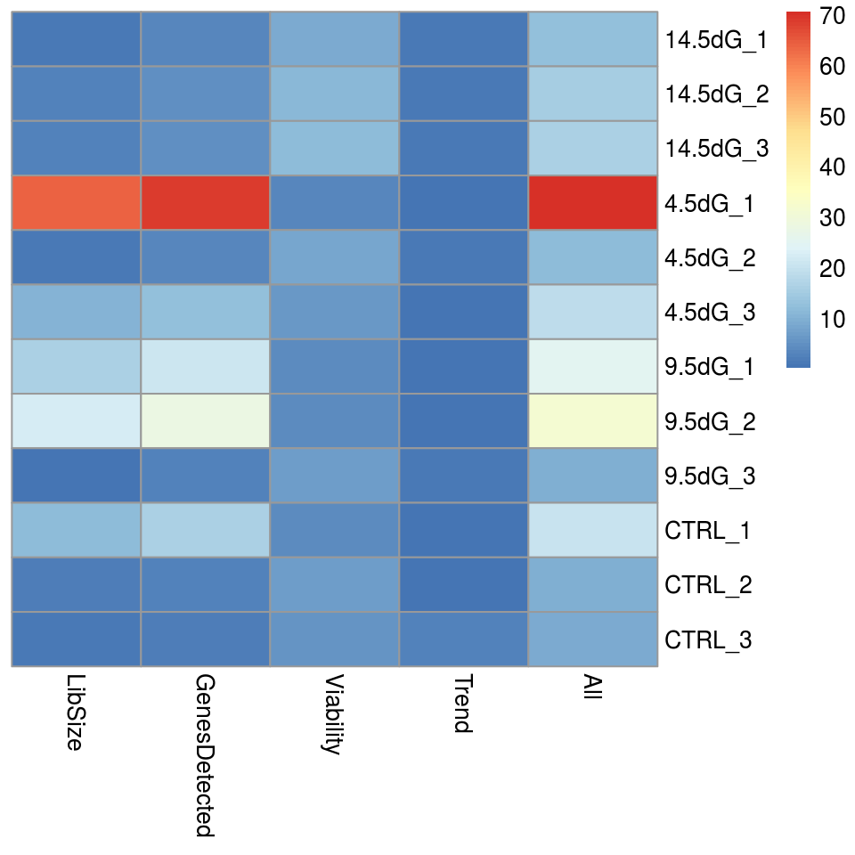

Heatmap visualizing percentage of cells removed by filtering.

```r
lsize <- t((table(pD$PassLibSize,pD$SampleID)))
lsize <- (lsize[,1]/rowSums(lsize))*100
pdect <- t((table(pD$PassGenesDetected,pD$SampleID)))
pdect <- (pdect[,1]/rowSums(pdect))*100
via <- t((table(pD$PassViability,pD$SampleID)))
via <- (via[,1]/rowSums(via))*100
trend <- t((table(pD$PassTrend,pD$SampleID)))
trend <- (trend[,1]/rowSums(trend))*100
pall <- t((table(pD$PassAll,pD$SampleID)))
pall <- (pall[,1]/rowSums(pall))*100

ovview <- data.frame("LibSize"=lsize,
             "GenesDetected"=pdect,
             "Viability"=via,
             "Trend"=trend,
             "All"=pall)

library(pheatmap)
pheatmap(ovview,cluster_rows=FALSE,
     cluster_cols=FALSE)
```

```r
kable(round(ovview,1))
```

|  | LibSize | GenesDetected | Viability | Trend | All |
| --- | --- | --- | --- | --- | --- |
| 14.5dG_1 | 1.5 | 3.3 | 9.2 | 0.9 | 12.6 |
| 14.5dG_2 | 2.6 | 4.4 | 10.9 | 1.3 | 15.4 |
| 14.5dG_3 | 2.3 | 4.5 | 11.6 | 1.1 | 16.0 |
| 4.5dG_1 | 64.1 | 68.7 | 3.5 | 0.2 | 70.7 |
| 4.5dG_2 | 1.3 | 3.2 | 8.6 | 1.1 | 11.6 |
| 4.5dG_3 | 10.0 | 12.8 | 6.1 | 0.8 | 18.6 |
| 9.5dG_1 | 16.3 | 21.1 | 4.3 | 0.5 | 25.3 |
| 9.5dG_2 | 22.6 | 28.2 | 3.7 | 0.4 | 31.9 |
| 9.5dG_3 | 0.8 | 2.5 | 6.9 | 1.0 | 9.4 |
| CTRL_1 | 11.6 | 16.0 | 4.3 | 0.8 | 20.2 |
| CTRL_2 | 2.1 | 2.8 | 6.9 | 0.2 | 9.5 |
| CTRL_3 | 1.0 | 1.9 | 5.3 | 2.6 | 9.2 |

## Sanity Check the trend filter

Based on the DE it seems to discard mainly red blood cells, which is fine.

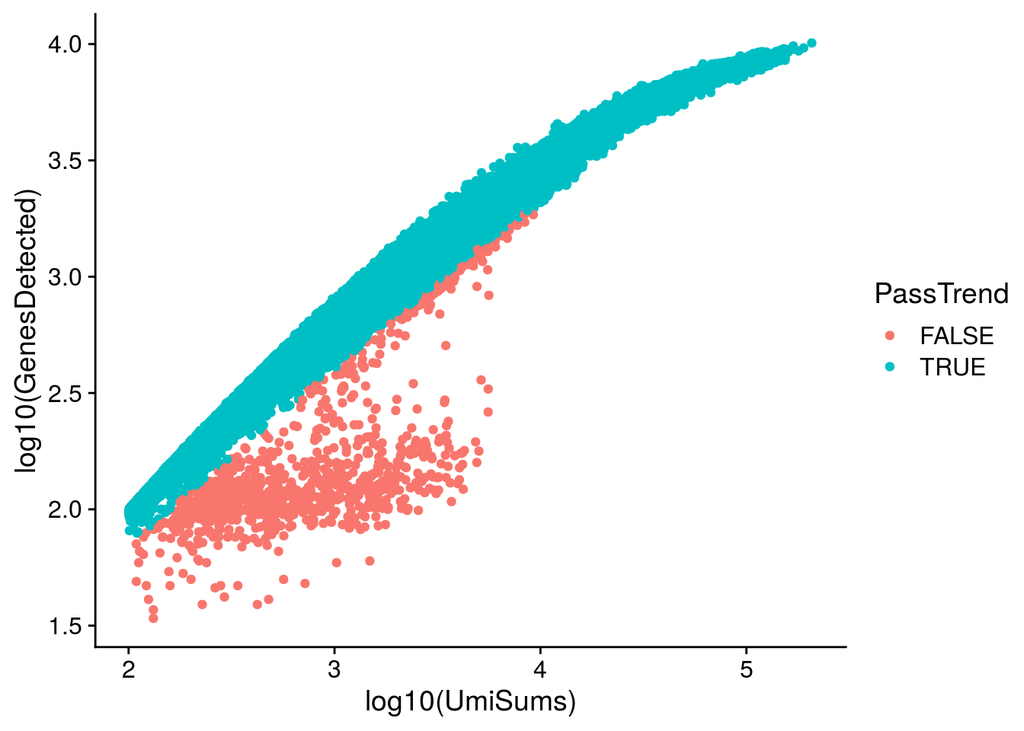

```r
ggplot(pD, aes(x=log10(UmiSums), y=log10(GenesDetected), color=PassTrend)) +
    geom_point()
```

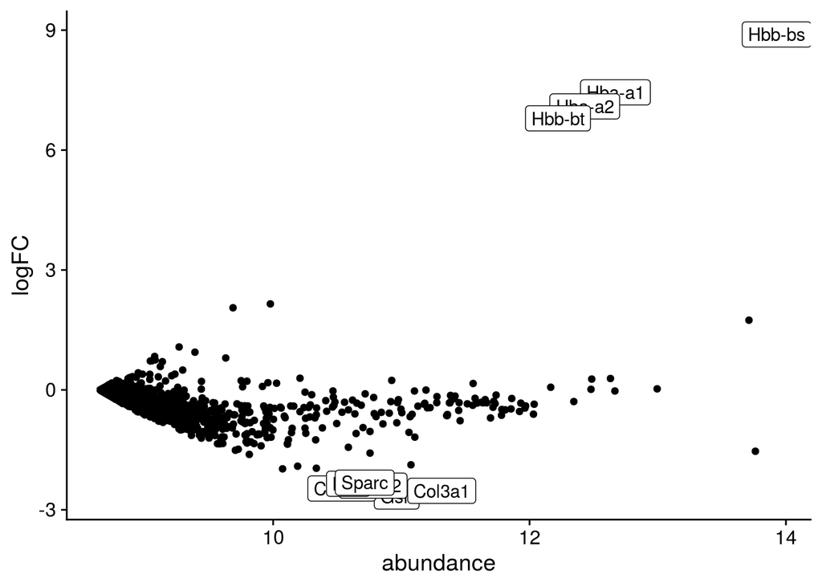

```r
lost <- calculateAverage(m[,!pD$PassTrend])
kept <- calculateAverage(m[,pD$PassTrend])

library(edgeR)
logged <- cpm(cbind(lost, kept), log=TRUE, prior.count=2)
logFC <- logged[,1] - logged[,2]
abundance <- rowMeans(logged)
fplot <- data.frame("abundance"=abundance,
            "logFC"=logFC,
            "Name"=names(logFC))
fplot <- arrange(fplot,desc(abs(logFC)))
ggplot(fplot, aes(x=abundance, y=logFC)) +
    geom_point() +
    geom_label(data=fplot[1:10,], aes(label=Name))
```

## Sanity Check QC overall

Here we perform DE between discarded and kept cells. Ideally you wouldn’t see any marker genes for particular cell types pop up.

- Overall we get rid of RBCs and dead cells, which is what we want.

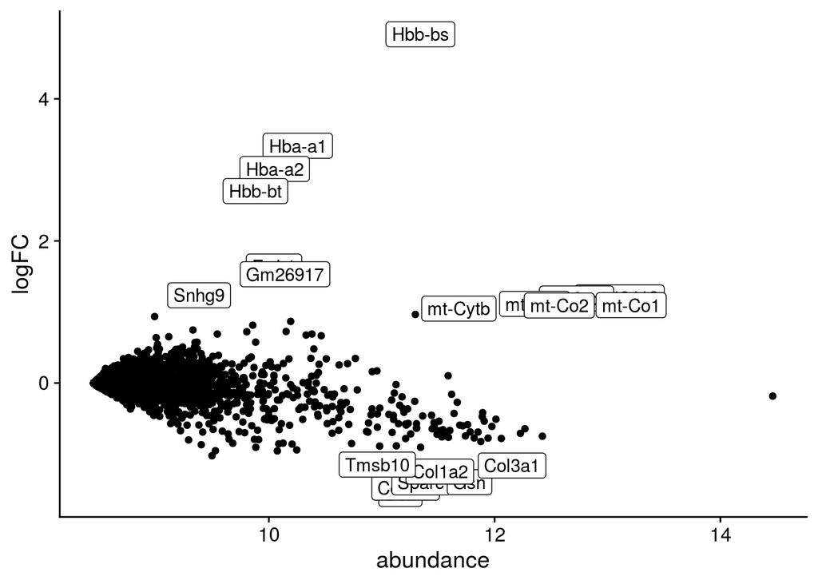

```r
lost <- calculateAverage(m[,!pD$PassAll])
kept <- calculateAverage(m[,pD$PassAll])

logged <- cpm(cbind(lost, kept), log=TRUE, prior.count=2)
logFC <- logged[,1] - logged[,2]
abundance <- rowMeans(logged)
fplot <- data.frame("abundance"=abundance,
            "logFC"=logFC,
            "Name"=names(logFC))
fplot <- arrange(fplot,desc(abs(logFC)))
ggplot(fplot, aes(x=abundance, y=logFC)) +
    geom_point() +
    geom_label(data=fplot[1:20,], aes(label=Name))
```

## Gene-wise

- At this stage I only remove genes without any reads

```r
keep <- rowSums(m)!=0
```

## Final data

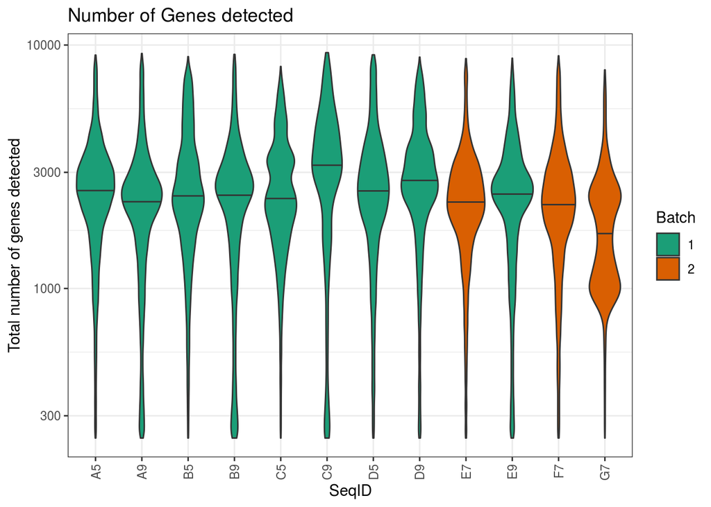

```r
pD <- pD[pD$PassAll,]
m <- m[keep,pD$barcode]
fD <- fD[keep,]
genesDetected %+% pD
```

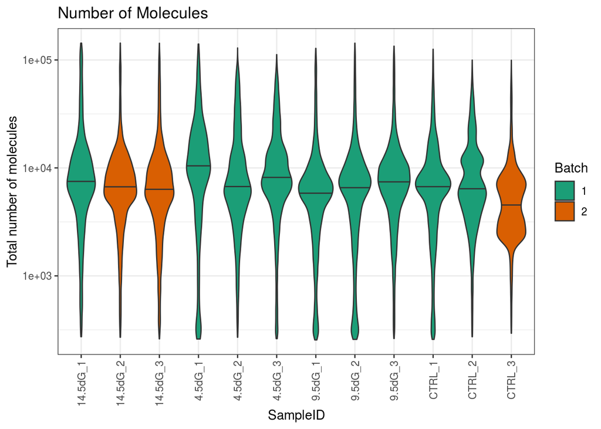

```r
LibrarySize %+% pD
```

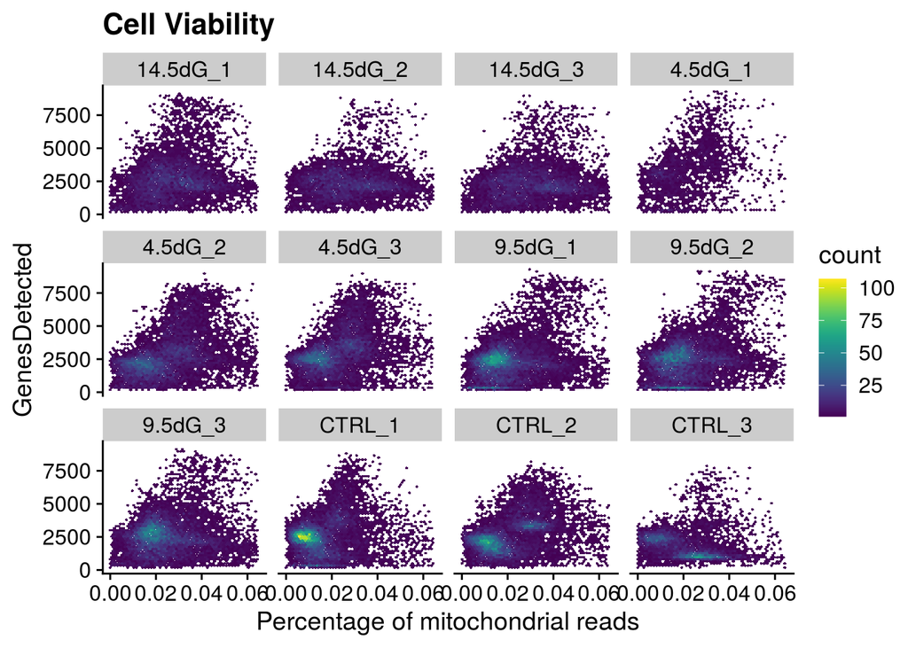

```r
cellViability %+% pD
```

## Save Data

```r
sceout <- SingleCellExperiment(assays=list(counts=m),
                   colData=pD,
                   rowData=fD)
saveRDS(sceout,file="../data/Robjects/SCE_QC.rds")
```